# Reproducible Research: Peer Assessment 1

## Loading and preprocessing the data

The assumption is made that the activity file has been downloaded and the working directory is set to where the data file is saved. The data is read and the data rows that are not complete are removed.

```r
   activityFile <- "activity.csv"
   if(file.exists(activityFile)) {
     activity <- read.csv(file=activityFile, sep=",", header=TRUE, skipNul=TRUE )
     activity.ignore.na <- activity[complete.cases(activity),]
     str(activity.ignore.na)

     require("lattice")
     activity$date <- as.Date(activity$date, "%Y-%m-%d")
   }
```

```
## 'data.frame':    15264 obs. of  3 variables:
##  $ steps   : int  0 0 0 0 0 0 0 0 0 0 ...
##  $ date    : Factor w/ 61 levels "2012-10-01","2012-10-02",..: 2 2 2 2 2 2 2 2 2 2 ...
##  $ interval: int  0 5 10 15 20 25 30 35 40 45 ...
```

## What is mean total number of steps taken per day?

1.) The total number of steps taken per day is calculated using the aggregate function

```r
   aggActivity <- aggregate(formula = steps ~ date, data = activity.ignore.na, FUN=sum)
```

2.) The histogram uses the the data generated in the above step to plot the steps taken per day

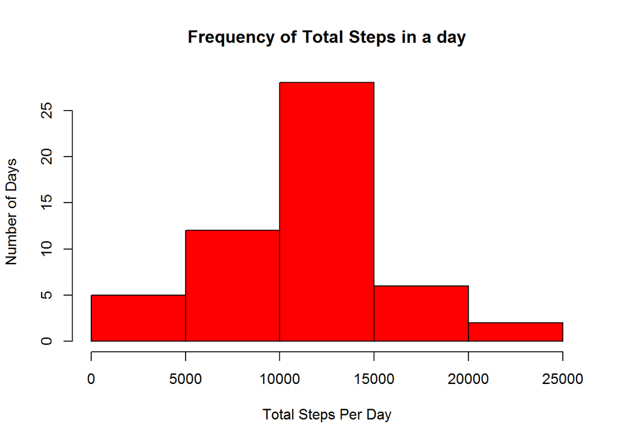

```r
   hist(aggActivity$steps,
        xlab = "Total Steps Per Day",
        ylab = "Number of Days",
        main = "Frequency of Total Steps in a day",
        col = c("red"))
```

The mean of the total number of steps taken per day is calculated as follows.

```r
   mean(aggActivity$steps)
```

```
## [1] 10766.19
```

The median of the total number of steps taken per day is calculated as follows.

```r
   median(aggActivity$steps)
```

```
## [1] 10765
```

The mean is 10766.19 and the median is 10765

## What is the average daily activity pattern?

1.) Make a time series plot (i.e. type = “l”) of the 5-minute interval (x-axis) and the average number of steps taken, averaged across all days (y-axis)

First create a dataset that caclulates the average number of steps taken across each day for a given interval.

Then a time series plot is generated.

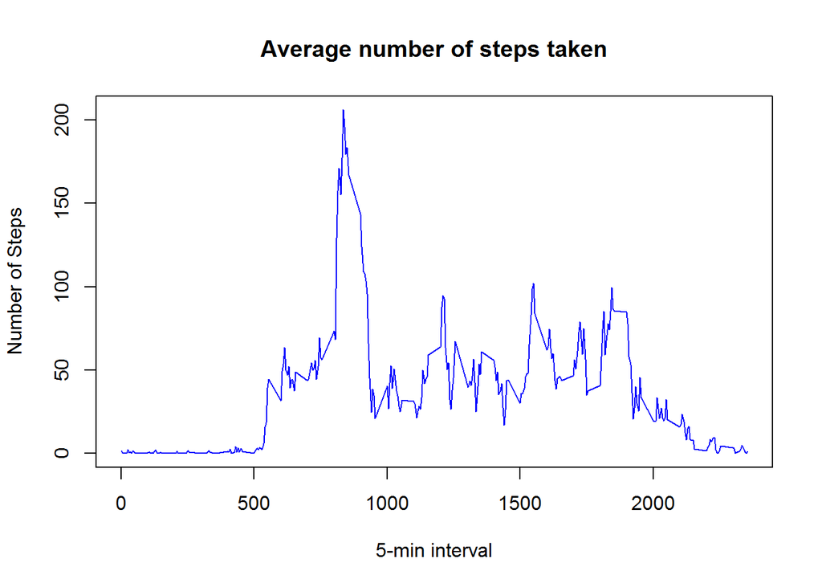

```r
   steps_per_interval <- aggregate(data=activity.ignore.na, steps ~ interval, FUN=mean)

   plot(x=steps_per_interval$interval,
        y = steps_per_interval$steps,
        type="l",
        xlab="5-min interval",
        ylab="Number of Steps",
        main="Average number of steps taken",
        col = "blue")
```

2.) Which 5-minute interval, on average across all the days in the dataset, contains the maximum number of steps?

```r
   max_interval <- steps_per_interval[which.max(steps_per_interval$steps),]
```

835 is the 5-minute interval and the maximum number of steps taken are approximately 206 steps.